# The magick package: Advanced Image-Processing in R

### Combining

Appending means simply putting the frames next to each other:

[figure not shown]

```r
image_append(image_scale(img, "x200"))
```

Use `stack = TRUE` to position them on top of each other:

[figure not shown]

```r
image_append(image_scale(img, "100"), stack = TRUE)
```

Composing allows for combining two images on a specific position:

[figure not shown]

```r
bigdatafrink <- image_scale(image_rotate(image_background(frink, "none"), 300), "x200")
image_composite(image_scale(bigdata, "x400"), bigdatafrink, offset = "+180+100")
```

### Pages

When reading a PDF document, each page becomes an element of the vector. Note that PDF gets rendered while reading so you need to specify the density immediately.

```r
manual <- image_read_pdf('https://cloud.r-project.org/web/packages/magick/magick.pdf', density = 72)
image_info(manual)
```

```
##    format width height colorspace matte filesize density
## 1     PNG   612    792       sRGB  TRUE        0   72x72
## 2     PNG   612    792       sRGB  TRUE        0   72x72
## 3     PNG   612    792       sRGB  TRUE        0   72x72
## 4     PNG   612    792       sRGB  TRUE        0   72x72
## 5     PNG   612    792       sRGB  TRUE        0   72x72
## 6     PNG   612    792       sRGB  TRUE        0   72x72
## 7     PNG   612    792       sRGB  TRUE        0   72x72
## 8     PNG   612    792       sRGB  TRUE        0   72x72
## 9     PNG   612    792       sRGB  TRUE        0   72x72
## 10    PNG   612    792       sRGB  TRUE        0   72x72
## 11    PNG   612    792       sRGB  TRUE        0   72x72
## 12    PNG   612    792       sRGB  TRUE        0   72x72
## 13    PNG   612    792       sRGB  TRUE        0   72x72
## 14    PNG   612    792       sRGB  TRUE        0   72x72
```

[output cut: 31 more lines]

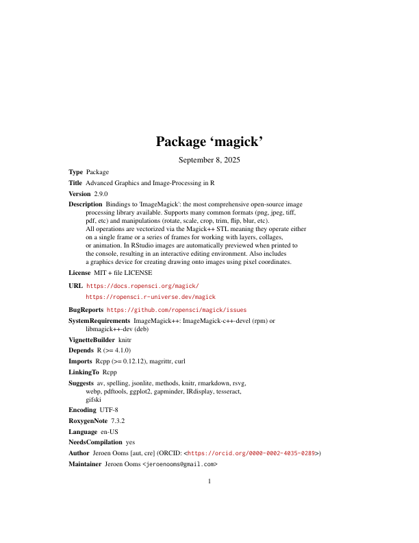

```r
manual[1]
```

### Animation

Instead of treating vector elements as layers, we can also make them frames in an animation!

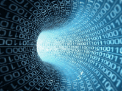

```r
image_animate(image_scale(img, "200x200"), fps = 1, dispose = "previous")
```

[figure not shown]

```r
newlogo <- image_scale(image_read("https://jeroen.github.io/images/Rlogo.png"))
oldlogo <- image_scale(image_read("https://jeroen.github.io/images/Rlogo-old.png"))
image_resize(c(oldlogo, newlogo), '200x150!') |>
  image_background('white') |>
  image_morph() |>
  image_animate(optimize = TRUE)
```

If you read in an existing GIF or Video file, each frame becomes a layer:

```r
# Foreground image
banana <- image_read("https://jeroen.github.io/images/banana.gif")
banana <- image_scale(banana, "150")
image_info(banana)
```

```
##   format width height colorspace matte filesize density
## 1    GIF   150    148       sRGB  TRUE        0   72x72
## 2    GIF   150    148       sRGB  TRUE        0   72x72
## 3    GIF   150    148       sRGB  TRUE        0   72x72
## 4    GIF   150    148       sRGB  TRUE        0   72x72
## 5    GIF   150    148       sRGB  TRUE        0   72x72
## 6    GIF   150    148       sRGB  TRUE        0   72x72
## 7    GIF   150    148       sRGB  TRUE        0   72x72
## 8    GIF   150    148       sRGB  TRUE        0   72x72
```

Manipulate the individual frames and put them back into an animation:

```
##   format width height colorspace matte filesize density
## 1    gif   200    155       sRGB  TRUE        0   72x72
## 2    gif    94    105       sRGB  TRUE        0   72x72
## 3    gif   125    122       sRGB  TRUE        0   72x72
## 4    gif   108    118       sRGB  TRUE        0   72x72
## 5    gif   108    105       sRGB  TRUE        0   72x72
## 6    gif    92    105       sRGB  TRUE        0   72x72
## 7    gif   113    123       sRGB  TRUE        0   72x72
## 8    gif   119    118       sRGB  TRUE        0   72x72
```

[figure not shown]

```r
# Background image
background <- image_background(image_scale(logo, "200"), "white", flatten = TRUE)

# Combine and flatten frames
frames <- image_composite(background, banana, offset = "+70+30")

# Turn frames into animation
animation <- image_animate(frames, fps = 10, optimize = TRUE)
print(animation)
```

Animations can be saved as GIF of MPEG files:

```r
image_write(animation, "Rlogo-banana.gif")
```

## Drawing and Graphics

A relatively recent addition to the package is a native R graphics device which produces a magick image object. This can either be used like a regular device for making plots, or alternatively to open a device which draws onto an existing image using pixel coordinates.

### Graphics device

The `image_graph()` function opens a new graphics device similar to e.g. `png()` or `x11()`. It returns an image object to which the plot(s) will be written. Each “page” in the plotting device will become a frame in the image object.

```r
# Produce image using graphics device
fig <- image_graph(width = 400, height = 400, res = 96)
ggplot2::qplot(mpg, wt, data = mtcars, colour = cyl)
dev.off()
```

We can easily post-process the figure using regular image operations.

```
## # A tibble: 1 × 7
##   format width height colorspace matte filesize density
##   <chr>  <int>  <int> <chr>      <lgl>    <int> <chr>
## 1 PNG      400    400 sRGB       TRUE         0 96x96
```

[figure not shown]

```r
# Combine
out <- image_composite(fig, frink, offset = "+70+30")
print(out)
```

### Drawing device

Another way to use the graphics device is to draw on top of an exiting image using pixel coordinates.

```r
# Or paint over an existing image
img <- image_draw(frink)
rect(20, 20, 200, 100, border = "red", lty = "dashed", lwd = 5)
abline(h = 300, col = 'blue', lwd = '10', lty = "dotted")
text(30, 250, "Hoiven-Glaven", family = "monospace", cex = 4, srt = 90)
palette(rainbow(11, end = 0.9))
symbols(rep(200, 11), seq(0, 400, 40), circles = runif(11, 5, 35),
  bg = 1:11, inches = FALSE, add = TRUE)
dev.off()
```

```r
print(img)
```

```
## # A tibble: 1 × 7
##   format width height colorspace matte filesize density
##   <chr>  <int>  <int> <chr>      <lgl>    <int> <chr>
## 1 PNG      220    445 sRGB       TRUE         0 72x72
```

[figure not shown]

By default `image_draw()` sets all margins to 0 and uses graphics coordinates to match image size in pixels (width x height) where (0,0) is the top left corner. Note that this means the y axis increases from top to bottom which is the opposite of typical graphics coordinates. You can override all this by passing custom `xlim`, `ylim` or `mar` values to `image_draw`.

### Animated Graphics

The graphics device supports multiple frames which makes it easy to create animated graphics. The code below shows how you would implement the example from the very cool [gganimate](https://gganimate.com/) package using the magick graphics device.

```
## # A tibble: 12 × 7
##    format width height colorspace matte filesize density
##    <chr>  <int>  <int> <chr>      <lgl>    <int> <chr>
##  1 gif      600    340 sRGB       TRUE         0 96x96
##  2 gif      385    243 sRGB       TRUE         0 96x96
##  3 gif      395    237 sRGB       TRUE         0 96x96
##  4 gif      374    232 sRGB       TRUE         0 96x96
##  5 gif      393    225 sRGB       TRUE         0 96x96
##  6 gif      373    234 sRGB       TRUE         0 96x96
##  7 gif      354    234 sRGB       TRUE         0 96x96
##  8 gif      308    210 sRGB       TRUE         0 96x96
##  9 gif      320    260 sRGB       TRUE         0 96x96
## 10 gif      331    218 sRGB       TRUE         0 96x96
## 11 gif      356    208 sRGB       TRUE         0 96x96
## 12 gif      347    208 sRGB       TRUE         0 96x96
```

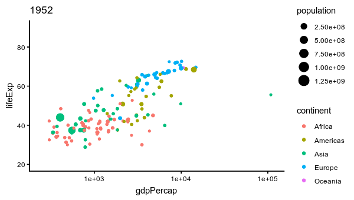

```r
library(gapminder)
library(ggplot2)
img <- image_graph(600, 340, res = 96)
datalist <- split(gapminder, gapminder$year)
out <- lapply(datalist, function(data){
  p <- ggplot(data, aes(gdpPercap, lifeExp, size = pop, color = continent)) +
    scale_size("population", limits = range(gapminder$pop)) + geom_point() + ylim(20, 90) +
    scale_x_log10(limits = range(gapminder$gdpPercap)) + ggtitle(data$year) + theme_classic()
  print(p)
})
dev.off()
animation <- image_animate(img, fps = 2, optimize = TRUE)
print(animation)
```

To write it to a file you would simply do:

```r
image_write(animation, "gapminder.gif")
```

## Raster Images

Magick images can also be converted to raster objects for use with R’s graphics device. Thereby we can combine it with other graphics tools. However do note that R’s graphics device is very slow and has a very different coordinate system which reduces the quality of the image.

### Base R rasters

Base R has an `as.raster` format which converts the image to a vector of strings. The paper [Raster Images in R Graphics](https://journal.r-project.org/articles/RJ-2011-008/) by Paul Murrell gives a nice overview.

[figure not shown]

```r
plot(as.raster(frink))
```

[figure not shown]

```r
# Print over another graphic
plot(cars)
rasterImage(frink, 21, 0, 25, 80)
```

### The `grid` package

The `grid` package makes it easier to overlay a raster on the graphics device without having to adjust for the x/y coordinates of the plot.

[figure not shown]

```r
library(ggplot2)
library(grid)
qplot(speed, dist, data = cars, geom = c("point", "smooth"))
grid.raster(frink)
```

## OCR text extraction

A recent addition to the package is to extract text from images using OCR. This requires the tesseract package:

```r
install.packages("tesseract")
```

```
## # A tibble: 1 × 7
##   format width height colorspace matte filesize density
##   <chr>  <int>  <int> <chr>      <lgl>    <int> <chr>
## 1 PNG      640    480 sRGB       TRUE     23359 72x72
```

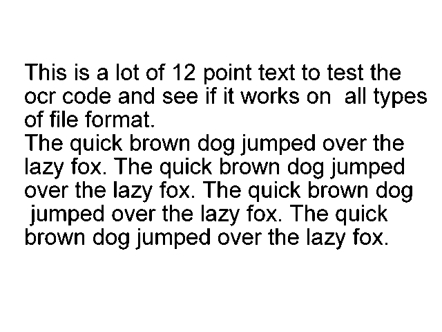

```r
img <- image_read("https://jeroen.github.io/images/testocr.png")
print(img)
```

```r
# Extract text
cat(image_ocr(img))
```

```
## This is a lot of 12 point text to test the
## ocr code and see if it works on all types
## of file format.
##
## The quick brown dog jumped over the
## lazy fox. The quick brown dog jumped
## over the lazy fox. The quick brown dog
## jumped over the lazy fox. The quick
## brown dog jumped over the lazy fox.
```